# Geodesics_questions_and_answers

## Raytracing a Schwarzchild Black Hole

This question is based on: https://rantonels.github.io/starless/

### Raytracing

We see physical objects when photons from sources of light travel along some path, possibly bouncing and scattering along the way before entering our eyes and forming an image on our retinas.

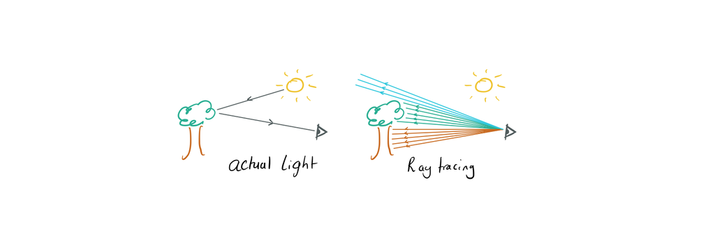

Raytracing is a method for rendering images that does this in reverse, for each pixel in the image we shoot a light ray out of a point at a different angle. By calculating what that ray intersects with we can decide how to colour that pixel.

In non-relativistic settings these rays are just straight lines, maybe bouncing off surfaces sometimes, but in GR we need to calculate the full geodesic of the ray. By doing this we will be able to produce simple schematic images of the distortions created by a black hole.

### The coding

In this problem set we're going to be working towards raycasting these schematic images of a Schwarzchild black hole.

The code will become a little involved as we work towards the payoff but I've tried to break it down into maneagble chunks.

If you get stuck, I've provided some hints with the idea that you should check them one at a time, and between each give yourself some time to try to arrive at the solution. It's likely that everyone will get a bit stuck at some point along the way so it's ok to sometimes take a peak at the answer to the part you're stuck on.

Once you're done with a question, check the answer before moving onto the next part.

### Question 1

The Schwarzchild metric is $$ds^2 = (1 - \tfrac{r_s}{r}) dt^2 - (1 - \tfrac{r_s}{r})^{-1} dr^2 - r^2 d\theta^2 - r^2 sin^2 \theta d\phi^2$$

Prove that for a photon travelling through the Schwarzchild metric in the $\theta = \pi / 2$ plane, we can eliminate $t$ in the geodesic equation to arrive at a differential equation for $r(\phi)$:

$$\tfrac{dr}{d\phi}^2 = a r^4 - (1 - r_s/r)(b r^4 + r^2)$$

for some constants $a$ and $b$.

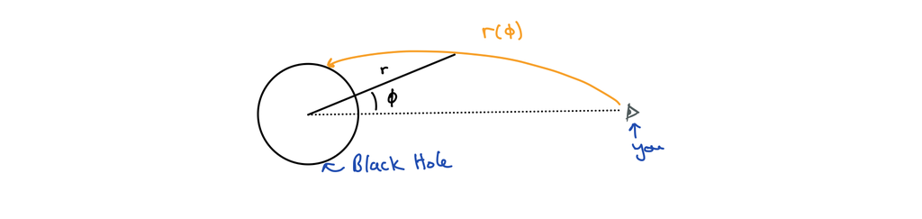

### Answer 1

The trick to do this without all the faff of calculating the Christoffel symbols is to use the Euler-Lagrange equations with the Lagrangian $L = g_{\mu\nu}\dot{x^\mu}\dot{x^\nu}$

$$\frac{dL}{dx^\mu} = \frac{d}{ds} \left(\frac{dL}{d\dot{x^\mu}}\right)$$

where $\tfrac{d}{ds}$ and dots are both derivatives w.r.t some parameter $s$.

Notice that the metric doesn't depend $\phi$ or $t$ so the EL equations equations for those coords give use two conserved quantities which we'll label $e$ and $l$ because they turn out to be energy and angular momentum. $$\dot{t}(1 - r_s/r) = e$$ $$\dot{\phi}r^2 = l$$

Check for youreslf that you can tranform this with $u = 1/r$ to get

$$\left(\frac{du}{d\phi}\right)^2 = \frac{e^2}{l^2} - (1 - r_s u)(\frac{1}{l^2 u^4} + \frac{1}{u^2})$$

Now there's one final detail before we start coding, this equation contains a square of a derivative which is a little annoying to work with numerically, solving it directly would require writing some quite low level numerical routines, instead what we'll do is convert this to a second order differential equation by taking another derivative w.r.t $\phi$. This is very similar to the relationship between $f = m\ddot{x}$ and $1/2 m \dot{x}^2 + V(x) = 0$. This gives us the equation we will actually be treating numerically:

$$\ddot{u} = -u (1 - \tfrac{3}{2} r_s u)$$

### Question 2

i) Recall that a 2nd order differential equation contains only derivatives like $\ddot{u}$ and $\dot{u}$ while a first order diff. eqn contains only terms like $\dot{u}$. Show that $\ddot{u} = -u (1 - \tfrac{3}{2} r_s u)$ can be written as two coupled first order equations by introducing a second variable.

ii) Read the documentation for `scipy.integrate.solve_ivp`, can you figure out how part i) helps us to use `solve_ivp` on our problem?

### Answer for 2

i) Introduce a new variable $v = \dot{u}$ so $\dot{v} = \ddot{u}$, this seems a little too obvious but now we have two first order equations! $$v = \dot{u}$$ $$\dot{v} = -u (1 - \tfrac{3}{2} r_s u)$$

ii) From the docs for `solve_ivp` we see that it can integrate equations of the form $\tfrac{dy}{dt} = f(t, y)$ with initial conditions $y(t_0) = y_0$ but crucially y can be of any dimension, so the trick is to write out coupled equations in a vector form, if we define: $$\vec{y} = (y_0, y_1) = (\dot{u}, u)$$ then we can write: $$\dot{y} = (\ddot{u}, \dot{u}) = (-y_1(1 - 3/2\; r_s y_1), y_0)$$

Which is something we can integrate with `solve_ivp`

### Question 3

i) First write a function `geodesic(u, udot, phi_max)` using that takes initial conditions $(u_0, \dot{u}_0)$ and returns a trajectory $u(\phi)$ represented by a numpy array of $\phi$ values and one of $u$ values with $\phi$ between 0 and `phi_max`.

ii) Now write a function `phi_u_to_xy(phi, u)` that transforms from $(u, \phi)$ coordinates to (x,y) coordinates.

iv) Reduce the maximum step size to something more reasonable like 0.2 to get a smoother plot.

### Hints for 3

1. Use scipy.integrate.solve_ivp
2. Read the docs for scipy.integrate.solve_ivp
3. Note that solve_ivp solves the equation dy/dt = f(y,t) where y may be an vector.

### Answer for 3

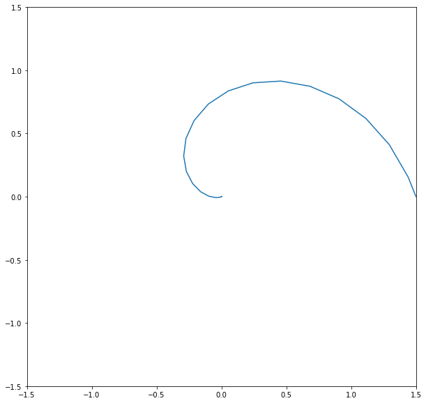

```python
import numpy as np
from scipy.integrate import solve_ivp
from matplotlib import pyplot as plt
from math import pi

def geodesic(u, udot, phi_max, r_s = 1, max_step = 0.2):
    """
    Integrates f(phi, y = (udot(phi), u(phi))) given inital data u and udot. For phi in (0, phi_max).
    The stepsize is variable but will not be larger than max_step so this can be used to get smoother plots of the trajectory.
    Returns phi, u such that (u[i], phi[i]) is the ith point along the trajectory. The number of points returned depends on the initial conditions, step size and stopping criteria.
    """
    def f(phi, y): return np.array([-y[1]*(1 - 3/2 * r_s * y[1]), y[0]])

    o = solve_ivp(
             fun = f,
             t_span = (0, phi_max),
             y0 = np.array([udot, u]),
             max_step = max_step,
             )

    return o.t, o.y[1]

def phi_u_to_xy(phi, u):
    r = 1/u
    return r*np.cos(phi), r*np.sin(phi)

phi, u = geodesic(u = 2/3, udot = 2/9, phi_max = 7)
x, y = phi_u_to_xy(phi, u)

f, ax = plt.subplots(figsize = (10,10))
ax.plot(x,y);
s = 1.5
ax.set(xlim = (-s,s), ylim = (-s,s));
```

### Question 4

i) Note that the point $u = 0$ corresponds to $r = \infty$, so it makes sense to stop the simulation at $u = 0$ because physically it means the photon has completely escaped the black hole and has shot off into space. Search the docs for `solve_ivp` for a way to implement this early stopping. If you don't do this you will notice spurious solutions later where $u$ has gone past 0 to small negative values. You'll notice that you actually get some spurious solutions anway when u gets very small so instead of stopping the simulation at $u = 0$ stop it at some large value like $r = 100$ (Don't forget $r = 1/u$).

ii) Write a function `r_rdot_to_u_udot(r, rdot)` that converts from $(r, \dot{r})$ to $(u, \dot{u})$

iii) Use the above to plot geodesics with the initial values $r = 3/2$ and $\dot{r}$ ranging between $-1$ and $0.1$ iv) Do another for $r = 3$ and $\dot{r}$ ranging between $-3$ and $-1$ but feel free to play around with the values.

Once you get the plots from iii you'll see that the photons either fall into the singularity or escape to infinity depending on their initial conditions, the two regimes are separated by an unstable circular orbit called the photon sphere that lies at $r = \tfrac{3}{2}r_s$

### Answer 4

Figuring out how to implement stop conditions in `solve_ivp` is a little odd but at least there's some example code in the documentation. Part ii) requires differentiating $r = 1/u$ to get the relationship between $\dot{r}$ and $\dot{u}$

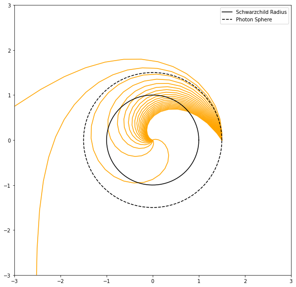

```python
#Tell the solver to stop when u = 0
#The solver triggers an event when stop_condition(t,y) == 0
#and because stop_condition(t, y).terminal == True it takes this as a signal to stop the simulation
def stop_condition(t, y): return y[1] - 1/100
stop_condition.terminal = True

def geodesic(u, udot, phi_max, r_s = 1, max_step = 0.2):
    """
    Integrates f(phi, y = (udot(phi), u(phi))) given inital data u and udot. For phi in (0, phi_max).
    The stepsize is variable but will not be larger than max_step so this can be used to get smoother plots of the trajectory.
    Returns phi, u such that (u[i], phi[i]) is the ith point along the trajectory. The number of points returned depends on the initial conditions, step size and stopping criteria.

    Stops if r grows larger than 100 * r_s, i.e the ray is going to infinity.
    """
    def f(phi, y): return np.array([-y[1]*(1 - 3/2 * r_s * y[1]), y[0]])

    o = solve_ivp(
             fun = f,
             t_span = (0, phi_max),
             y0 = np.array([udot, u]),
             max_step = max_step,
             events = stop_condition,
             )

    return o.t, o.y[1]

def phi_u_to_xy(phi, u):
    r = 1/u
    return r*np.cos(phi), r*np.sin(phi)

def r_rdot_to_u_udot(r, rdot):
    udot = - rdot / r**2
    u = 1/r
    return u, udot


r = 1.5 #The radius to shoot the rays from
s = 3 #The radius to include in the plot

fig, ax = plt.subplots(figsize = (10,10))
ax.set(xlim = (-s,s), ylim = (-s,s))

for rdot in np.linspace(-1,0.1,20):
    u, udot = r_rdot_to_u_udot(r, rdot)
    phi, u = geodesic(u, udot, phi_max = 10)
    x, y = phi_u_to_xy(phi, u)


    ax.plot(x,y, color = 'orange')
    #ax.scatter(x,y)

#Show important regions
phi = np.linspace(0,2*np.pi,100)
ax.plot(1*np.cos(phi), 1*np.sin(phi), linestyle = '-', color = 'black', label = "Schwarzchild Radius")
ax.plot(1.5*np.cos(phi), 1.5*np.sin(phi), linestyle = '--', color = 'black', label = "Photon Sphere")

ax.legend();
```

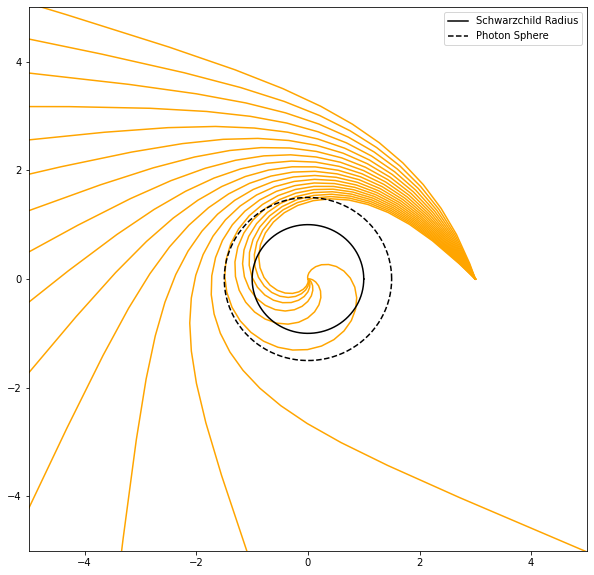

```python
r = 3 #The radius to shoot the rays from
s = 5 #The radius to include in the plot

fig, ax = plt.subplots(figsize = (10,10))
ax.set(xlim = (-s,s), ylim = (-s,s))

for rdot in np.linspace(-3,-1,20):
    u, udot = r_rdot_to_u_udot(r, rdot)
    phi, u = geodesic(u, udot, phi_max = 10)
    x, y = phi_u_to_xy(phi, u)


    ax.plot(x,y, color = 'orange')
    #ax.scatter(x,y)

#Show important regions
phi = np.linspace(0,2*np.pi,100)
ax.plot(1*np.cos(phi), 1*np.sin(phi), linestyle = '-', color = 'black', label = "Schwarzchild Radius")
ax.plot(1.5*np.cos(phi), 1.5*np.sin(phi), linestyle = '--', color = 'black', label = "Photon Sphere")

ax.legend()
```

### Question 5

i) We started off with $(\dot{u}, u)$ initial conditions and then moved to using $(\dot{r}, r)$. Now define $(\alpha, r)$ where $\alpha$ is the angle between the rays tangent and the horizontal.

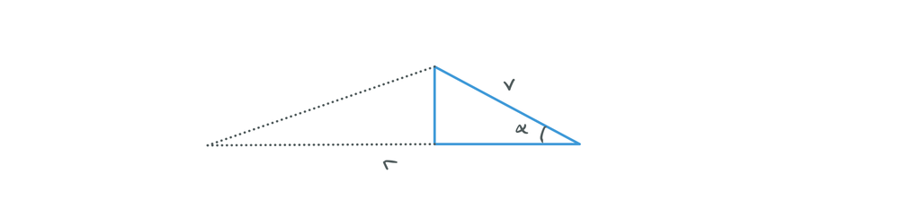

ii) What we're working towards is to determine if each ray goes to infinity or hits the event horizon and where. We're going to do this by taking advantage of `solve_ivp`'s ability to tell us about events, we've already used it to stop the simulation at $u = 0$. So let's define another event that fires if the ray hits the event horizon at u = 1, we'll then be able to classify rays into those that escaped and those that were captured by the black hole.

NB: if you pass `events = [f, g]` into `solve_ivp` then the solution will have a field `t_events` where `t_events[0]` contains t values at which $f(t,y) = 0$ and `t_events[1]` at which $g(t,y) = 0$

You'll see that the lines actually overshoot the event horizon and go a little inside, don't worry about this, it's just because of the finite step size. The events actually have more accurate positions than the steps themselves because `solve_ivp` uses numerical root finding under the hood to estimate where $f(t,y) = 0$ even if it happens between steps.

### Answer 5

i)

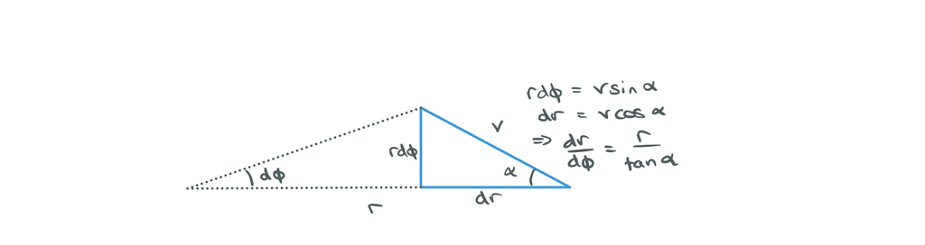

ii)

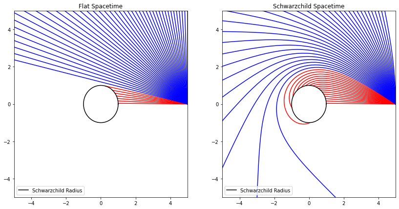

```python
def escape(t, y): return y[1] - 1/100
escape.terminal = True

def horizon(t, y): return y[1] - 1
horizon.terminal = True

def geodesic(u, udot, phi_max, r_s = 1, max_step = 0.1):
    """
    Integrates f(phi, y = (udot(phi), u(phi))) given inital data u and udot. For phi in (0, phi_max).
    The stepsize is variable but will not be larger than max_step so this can be used to get smoother plots of the trajectory.
    Returns phi, u, o such that (u[i], phi[i]) is the ith point along the trajectory.
    o is the full result object returned by solve_ivp which contains, among other things, information about events that occured on the trajectory.

    The number of points returned depends on the initial conditions, step size and stopping criteria.

    Stops if r grows larger than 100 * r_s, i.e the ray is going to infinity
    or if r < 1 in which case the ray has crossed the event horizon.
    """
    def f(phi, y): return np.array([-y[1]*(1 - 3/2 * r_s * y[1]), y[0]])
    o = solve_ivp(
             fun = f,
             t_span = (0, phi_max),
             y0 = np.array([udot, u]),
             max_step = max_step,
             events = [escape, horizon],
             )
    return o.t, o.y[1], o

fig, axes = plt.subplots(ncols = 2, figsize = (14,7))

r = 5
s = 5


for r_s, ax in zip([0,1],axes):
    ax.set(xlim = (-s,s), ylim = (-s,s))

    for alpha in np.linspace(0.01, pi/2 ,50):
        rdot = -r/np.tan(alpha)

        u, udot = r_rdot_to_u_udot(r, rdot)
        phi, u, o = geodesic(u, udot, phi_max = 10, r_s = r_s)
        x, y = phi_u_to_xy(phi, u)

        color = "blue" if len(o.t_events[0]) > 0 else "red"

        ax.plot(x,y, color = color)

    phi = np.linspace(0,2*np.pi,100)
    ax.plot(1*np.cos(phi), 1*np.sin(phi), linestyle = '-', color = 'black', label = "Schwarzchild Radius")
    ax.legend()

axes[0].set(title = "Flat Spacetime")
axes[1].set(title = "Schwarzchild Spacetime");
```

At this point we should stop and think about what this is. We're calculating geodesics emanating from an observer at some point outside the horizon. If we want to interpret what this means about how a black hole looks we have to be careful:

1) When doing raytracing we're assuming the geodesics are reversible, that is: light could follow a path from the surface of the horizon to the observer. You'll have to take my word that this is true in this case, though you can easily see that it isn't true for points inside the event horizon. 2) The other thing to note is that when matter falls into a black hole, light that it emits will appear more and more redshifted until it's essentially invisible. We're not going to account for that here.

That being said, the above plots tell us two things about what black hole look like:

1) The horizon appears larger than it actually is. 2) We are able to see light that is emitted from the back, side and actually all the way around the hole. If you add more rays you'll see there's no limit to how many loops the light rays can make, it just requires more and more tuning of the angle. This means that at the edge of our image of the hole we're going to see a lot of copies of the hole all smushed together.